# C8_PML_W4_A

Amyn

September 19, 2016

# What to Submit

- A link to a Github repo with your R markdown and compiled HTML file describing your analysis.
- Please constrain the text of the writeup to < 2000 words and the number of figures to be less than 5.
- Submit a repo with a gh-pages branch so the HTML page can be viewed online (and you always want to make it easy on graders :-).

# Background

Using devices such as Jawbone Up, Nike FuelBand, and Fitbit it is now possible to collect a large amount of data about personal activity relatively inexpensively.

These type of devices are part of the quantified self movement – a group of enthusiasts who take measurements about themselves regularly to improve their health, to find patterns in their behavior, or because they are tech geeks.

One thing that people regularly do is quantify how much of a particular activity they do, but they rarely quantify how well they do it.

More information is available from the website here: http://groupware.les.inf.puc-rio.br/har (see the section on the Weight Lifting Exercise Dataset).

# Data & Package Loading

## Package Loading

```r
library(caret)      ### Load the CARET Package for modeling
```

```r
library(ggplot2)    ### Load the GGPLOT2 Package for Data Visualization and Analysis
set.seed(1234)      ### Set seed so that we can ensure that we can recreate our results for testing purposes
library(data.table)
library(quantmod)
library(randomForest)
library(rpart)
library(rpart.plot)
setwd("~/Documents/R Working Directory/Course_8_Practical_Machine_Learning")    ### Set the Working Directory
```

## Load the Data

The training and test data for this project are available using the following links: * https://d396qusza40orc.cloudfront.net/predmachlearn/pml-training.csv * https://d396qusza40orc.cloudfront.net/predmachlearn/pml-testing.csv

```r
url <- "https://d396qusza40orc.cloudfront.net/predmachlearn/pml-training.csv"
f <- file.path(getwd(), "pml-training.csv")
 download.file(url, f)  ### Commenting out the download to simplify testing
train<- read.csv(f, na.strings = c("NA","#DIV/0!", ""))

url <- "https://d396qusza40orc.cloudfront.net/predmachlearn/pml-testing.csv"
f <- file.path(getwd(), "pml-testing.csv")
 download.file(url, f) ### Commenting out the download to simplify the testing
validation<- read.csv(f, na.strings = c("NA","#DIV/0!", ""))
```

# Data Cleansing + Transformation

```r
#dim(train)
#dim(validation)
train<-train[,colSums(is.na(train)) == 0]   ### Remove all columns that have nothing but NAs - there column sum will not be 0
validation <-validation[,colSums(is.na(validation)) == 0]     ### Remove all columns that have nothing but NAs - there column sum will not be 0
train <- train[,-c(1:7)]    ### Remove the first 7 columns of qualitative data as they are not required for our model
validation <-validation[,-c(1:7)]       ### Remove the first 7 columns of qualitative data as they are not required for our model
#dim(train)
#dim(validation)
```

We will now partition the training set for cross validation testing activities

```r
inTrain <-createDataPartition(y=train$classe, p = 0.75, list = FALSE)
subTrain <- train[inTrain,] ### Create our Training Set
subTest <-train[-inTrain,]  ### Create our Testing Set
#dim(subTrain)
#dim(subTest)
```

# Modeling

Based on my explorartory analysis I have chosen to use the RandomForest method to create my predictive model. I have chosen this method as: * The General Linear Model (GLM) failed as there was not a linear relationship in the data * The Generalized Additive Model (GAM) failed to complete complete it prediction due to the size of the data set and my limited computing power * The Random Forest Model is able to discover more complex dependencies at the cost of more time for fitting

Given the number of samples I’ve chosen 10 Fold Cross Validation

```r
mod_rf <- train(classe ~ ., data = subTrain, method = "rf", trControl = trainControl(method="cv"), number = 10)
mod_rf$finalModel
```

```
##
## Call:
##  randomForest(x = x, y = y, mtry = param$mtry, number = 10)
##                Type of random forest: classification
##                      Number of trees: 500
## No. of variables tried at each split: 2
##
##         OOB estimate of  error rate: 0.63%
## Confusion matrix:
##      A    B    C    D    E  class.error
## A 4181    3    0    1    0 0.0009557945
## B   17 2826    5    0    0 0.0077247191
## C    0   18 2544    5    0 0.0089598753
## D    0    0   35 2375    2 0.0153399668
## E    0    0    1    5 2700 0.0022172949
```

We will also look to see what are the most and least important variables for our model

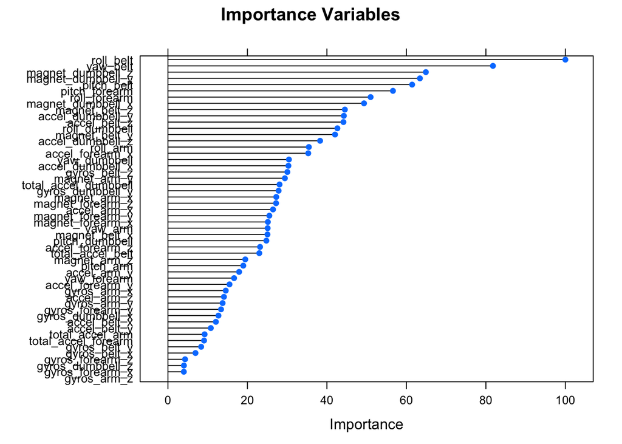

```r
varImpObj <- varImp(mod_rf)
plot(varImpObj, main = "Importance Variables", top = (ncol(subTrain)-1))
```

So we can see that the ROLL_BELT, YAW_BELT & MAGNET_DUBMBELL_Z are the most important, while the GYROS_ARM_Z, GYROS_FOREARM_X and GYROS_DUMBELL_Z are the least imporant in our prediction model.

We will then do the Prediction and review the accuracy and cross correlation with our test data set

```r
pred_rf_T <- predict(mod_rf, subTest)
confusionMatrix(pred_rf_T,subTest$classe)
```

```
## Confusion Matrix and Statistics
##
##           Reference
## Prediction    A    B    C    D    E
##          A 1393    4    0    0    0
##          B    2  945   15    0    0
##          C    0    0  839   13    0
##          D    0    0    1  791    0
##          E    0    0    0    0  901
##
## Overall Statistics
##
##                Accuracy : 0.9929
##                  95% CI : (0.9901, 0.995)
##     No Information Rate : 0.2845
##     P-Value [Acc > NIR] : < 2.2e-16
##
##                   Kappa : 0.991
##  Mcnemar's Test P-Value : NA
##
## Statistics by Class:
##
##                      Class: A Class: B Class: C Class: D Class: E
## Sensitivity            0.9986   0.9958   0.9813   0.9838   1.0000
## Specificity            0.9989   0.9957   0.9968   0.9998   1.0000
## Pos Pred Value         0.9971   0.9823   0.9847   0.9987   1.0000
## Neg Pred Value         0.9994   0.9990   0.9961   0.9968   1.0000
## Prevalence             0.2845   0.1935   0.1743   0.1639   0.1837
## Detection Rate         0.2841   0.1927   0.1711   0.1613   0.1837
## Detection Prevalence   0.2849   0.1962   0.1737   0.1615   0.1837
## Balanced Accuracy      0.9987   0.9957   0.9890   0.9918   1.0000
```

From the test we can see that the RandomForest Model works very well our test data set with an Accuracy of 99.3% and a Confidence Interval of 99.% to 99.5%.

# Final Validation & Output

We will now do a final validation of the model using the validation data set and output the results to a set of final for confirmation.

```r
pred_rf_V <-predict(mod_rf,validation)
pred_rf_V
```

```
##  [1] B A B A A E D B A A B C B A E E A B B B
## Levels: A B C D E
```

```r
answers <- as.vector(pred_rf_V)
pml_write_files = function(x) {
    n = length(x)
    for (i in 1:n) {
        filename = paste0("Problem_id_", i, ".txt")
        write.table(x[i], file = filename, quote = FALSE, row.names = FALSE,
            col.names = FALSE)
    }
}
pml_write_files(answers)
```

# Acknowledgements

- Data from this project was sourced from http://groupware.les.inf.puc-rio.br/har